# Inferencia Estadística

Unidad 5 — Correlación y Regresión Lineal

Práctica · Lic. en Economía · UNNE

2026-05-13

# Fundamentos: Esperanza y Varianza

## Valor Esperado o Esperanza

Ya trabajamos con la **media poblacional** $\mu_y$ de una variable aleatoria $y$. Otra forma de escribirla es como el **valor esperado** o **esperanza** de $y$:

$$E(y) = \mu_y$$

Así, toda variable aleatoria puede descomponerse como:

$$y = \underbrace{E(y)}_{\text{media}} + \underbrace{u}_{\text{desviación}}$$

donde $u = y - E(y)$ son las **desviaciones respecto de la media**, con $E(u) = 0$ por construcción.

> Esta descomposición es el germen del modelo de regresión: una parte **sistemática** y una parte **aleatoria**.

## Propiedades del Valor Esperado

Sean $a$, $b$ constantes e $y$, $x$ variables aleatorias:

| Propiedad | Expresión |
| --- | --- |
| Linealidad | $E(a + by) = a + b\,E(y)$ |
| Suma | $E(y + x) = E(y) + E(x)$ |
| Constante | $E(a) = a$ |
| Independencia | Si $y \perp x$: $E(y \cdot x) = E(y)\cdot E(x)$ |

**Consecuencia importante:** si $a$ y $b$ son constantes,

$$E(a + by + cx) = a + b\,E(y) + c\,E(x)$$

> La esperanza es un **operador lineal**: “pasa a través” de sumas y multiplicaciones por constantes.

## Varianza

La **varianza** de $y$ mide la dispersión de $y$ alrededor de su media:

$$\text{Var}(y) = \sigma^2_y = E\!\left[(y - E(y))^2\right] = E(y^2) - [E(y)]^2$$

Propiedades (con $a$, $b$ constantes):

| Propiedad | Expresión |
| --- | --- |
| Constante | $\text{Var}(a) = 0$ |
| Escala | $\text{Var}(a + by) = b^2\,\text{Var}(y)$ |
| Suma (indep.) | $\text{Var}(y + x) = \text{Var}(y) + \text{Var}(x)$ si $y \perp x$ |

La **desviación estándar** es $\sigma_y = \sqrt{\text{Var}(y)}$, en las mismas unidades que $y$.

## Covarianza

La **covarianza** entre dos variables $y$ y $x$ mide si se mueven en la misma dirección:

$$\text{Cov}(y, x) = \sigma_{yx} = E\!\left[(y - E(y))(x - E(x))\right] = E(yx) - E(y)\,E(x)$$

**$\text{Cov} > 0$** Cuando $x$ sube, $y$ tiende a subir.

**$\text{Cov} < 0$** Cuando $x$ sube, $y$ tiende a bajar.

**$\text{Cov} = 0$** No hay asociación lineal.

Propiedades útiles:

- $\text{Cov}(y, y) = \text{Var}(y)$
- $\text{Cov}(a + by,\; c + dx) = bd\;\text{Cov}(y, x)$
- Si $y \perp x$: $\text{Cov}(y, x) = 0$ (el recíproco no siempre vale)

# Correlación

## El Coeficiente de Correlación

La covarianza depende de las **unidades** de medida: no permite comparar asociaciones entre distintos pares de variables.

El **coeficiente de correlación** de Pearson estandariza la covarianza:

$$\rho_{yx} = \frac{\text{Cov}(y, x)}{\sigma_y\;\sigma_x} = \frac{\sigma_{yx}}{\sigma_y\;\sigma_x}$$

Propiedades:

- $-1 \leq \rho_{yx} \leq 1$ (adimensional)
- $\rho = 1$: relación lineal perfecta positiva
- $\rho = -1$: relación lineal perfecta negativa
- $\rho = 0$: sin asociación **lineal** (puede existir relación no lineal)

> **¡Cuidado!** $\rho = 0$ no implica independencia. Solo descarta la asociación **lineal**.

## Correlación: visualización

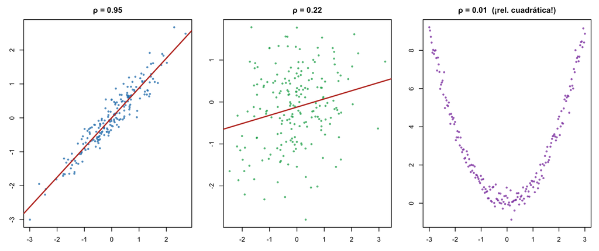

> El panel derecho muestra que $\rho \approx 0$ no significa ausencia de relación.

## Correlación muestral

Con datos observados $(x_i, y_i)$, $i = 1, \ldots, n$, estimamos $\rho$ con:

$$r_{yx} = \frac{\sum_{i=1}^n (y_i - \bar y)(x_i - \bar x)}{\sqrt{\sum_{i=1}^n (y_i-\bar y)^2}\;\sqrt{\sum_{i=1}^n (x_i - \bar x)^2}}$$

En R:

```r
set.seed(44)
x <- 10 + rnorm(1000, 0, 2)
y <- 20 + 0.5*x + rnorm(1000, 0, 1)

cor(x, y)          # correlación muestral
```

```
[1] 0.7220919
```

```r
cov(x, y)          # covarianza muestral
```

```
[1] 2.055616
```

> La función `cor()` devuelve $r_{yx}$; `cov()` devuelve $\hat\sigma_{yx}$. Ambos son estimadores consistentes de sus análogos poblacionales.

## Test de hipótesis sobre $\rho$

¿Es la correlación poblacional significativamente distinta de cero?

$$H_0: \rho = 0 \quad \text{vs.} \quad H_1: \rho \neq 0$$

Bajo $H_0$ y normalidad, el estadístico:

$$t = \frac{r\,\sqrt{n-2}}{\sqrt{1-r^2}} \sim t_{n-2}$$

```r
cor.test(x, y)
```

```
    Pearson's product-moment correlation

data:  x and y
t = 32.975, df = 998, p-value < 2.2e-16
alternative hypothesis: true correlation is not equal to 0
95 percent confidence interval:
 0.6910327 0.7504895
sample estimates:
      cor
0.7220919
```

> `cor.test()` reporta el estadístico $t$, los grados de libertad y el $p$-valor. Si $p < \alpha$ rechazamos $H_0$ y concluimos que existe asociación lineal significativa.

# De la Correlación a la Regresión

## Esperanza Condicional

Si $(y, x)$ están correlacionadas, la **media de $y$ puede cambiar según el valor de $x$**.

Generalizando $E(y) = \mu_y$, definimos la **esperanza condicional**:

$$E(y \mid x) = \mu_{y|x}$$

Esto significa: ¿cuál es el valor promedio de $y$ para un valor fijo de $x$?

**Incondicional:** $E(y) = \mu_y$ — un único número.

**Condicional:** $E(y \mid x)$ — una **función** de $x$.

> La función de esperanza condicional describe cómo cambia el promedio de $y$ a medida que varía $x$. La regresión lineal es un modelo para esa función.

## Del Esperanza Condicional al Modelo

Si modelamos $E(y \mid x)$ como una función **lineal** de $x$:

$$E(y \mid x) = \beta_0 + \beta_1 x$$

Como $y = E(y \mid x) + u$, obtenemos el **Modelo de Regresión Lineal Simple (MRL)**:

$$\boxed{y = \beta_0 + \beta_1 x + u}$$

donde:

- $\beta_0$: **intercepto** (valor esperado de $y$ cuando $x = 0$)
- $\beta_1$: **pendiente** (cambio en $E(y \mid x)$ ante un incremento unitario en $x$)
- $u$: **término de error** o perturbación (desviación de cada observación respecto de la recta poblacional)

Por construcción: $E(u \mid x) = 0$.

## Terminología del MRL

En el modelo $y = \beta_0 + \beta_1 x + u$:

**Variable $y$** se llama:

- Variable dependiente
- Variable explicada
- Regresando

**Variable $x$** se llama:

- Variable independiente
- Variable explicativa
- Regresor / Co-variable

**“Lineal”** se refiere a los **parámetros** ($\beta_0, \beta_1$), no necesariamente a las variables. Por ejemplo:

$$y = \beta_0 + \beta_1 x^2 + u \quad \text{también es lineal (en parámetros)}$$

**“Simple”** indica una sola variable explicativa. Con $k$ regresores tenemos el **Modelo de Regresión Múltiple**:

$$y = \beta_0 + \beta_1 x_1 + \beta_2 x_2 + \cdots + \beta_k x_k + u$$

## Ejemplos del MRL

El modelo $y = \beta_0 + \beta_1 x + u$ admite infinitas aplicaciones:

| Variable dependiente ($y$) | Variable explicativa ($x$) |
| --- | --- |
| Ventas totales | Tiempo |
| Gasto en viajes | Ingresos |
| Ventas | Gasto en publicidad |
| Horas de sueño | Horas de trabajo |
| Salario (wage) | Coeficiente intelectual (IQ) |
| Participación en plan de pensión | Generosidad del plan (mrate) |

> **Interpretación de $\beta_1$**: un incremento de una unidad en $x$ produce un cambio de $\beta_1$ unidades en $E(y \mid x)$, **sin importar el valor inicial de $x$** — eso es la linealidad.

## El término de error $u$

El componente aleatorio del modelo es $u$.

En $u$ se encuentran **todos los factores que afectan a $y$ y que no se incluyeron como regresores**:

- En un modelo de salarios sobre educación: habilidad innata, experiencia, motivación…
- En un modelo de ventas sobre publicidad: calidad del producto, estacionalidad, competencia…

**¿Podemos suponer $E(u) = 0$?**

$$E(u) = 0$$

Sí, y **no es restrictivo**: siempre podemos usar $\beta_0$ para normalizar $E(u)$ a cero. Entonces $\beta_0$ puede interpretarse como el promedio de los factores inobservables en la población.

## Visualizando el MRL

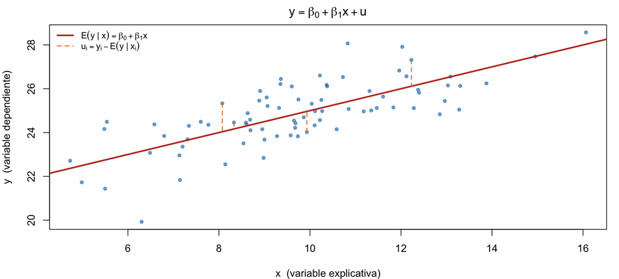

## El supuesto clave: $E(u \mid x) = 0$

El supuesto verdaderamente importante no es $E(u)=0$ sino que $u$ sea **independiente de $x$ en media**:

$$E(u \mid x) = E(u) = 0$$

Esto implica directamente que la recta poblacional es la verdadera esperanza condicional:

$$E(y \mid x) = \beta_0 + \beta_1 x$$

> Sin este supuesto, la regresión ajusta una recta pero **no recupera el efecto causal** de $x$ sobre $y$. Más adelante se entenderá por qué es tan crucial para la interpretación del modelo.

## Cuando el supuesto se viola

**¿Cuándo falla $E(u \mid x) = 0$?** Cuando $x$ está correlacionada con factores incluidos en $u$:

| Ejemplo | $x$ | Factor en $u$ correlacionado con $x$ |
| --- | --- | --- |
| Retorno a educación | años de estudio | habilidad innata |
| Efecto publicidad | gasto en publicidad | calidad del producto |
| Ingreso ~ educación | educación | experiencia laboral |

En ese caso se dice que hay una **variable omitida** y el estimador MCO queda sesgado:

$$\hat\beta_1 \xrightarrow{p} \beta_1 + \underbrace{\text{sesgo}}_{\neq 0}$$

> Veremos esto en detalle con el ejercicio de simulación: `ingreso ~ educacion` sin controlar `experiencia`.

# Estimación por MCO

## De la población a la muestra

Tenemos una **muestra aleatoria** de tamaño $n$: $\{(x_i, y_i): i = 1, \ldots, n\}$.

Cada observación satisface el modelo poblacional:

$$y_i = \beta_0 + \beta_1 x_i + u_i$$

La idea de la regresión es **estimar** los parámetros poblacionales ($\beta_0$ y $\beta_1$) usando la muestra, para obtener la **recta ajustada**:

$$\hat{y}_i = \hat{\beta}_0 + \hat{\beta}_1 x_i$$

y los **residuos** (análogos muestrales del error $u_i$):

$$\hat{u}_i = y_i - \hat{y}_i = y_i - \hat{\beta}_0 - \hat{\beta}_1 x_i$$

> $\hat{u}_i$ es la diferencia entre el valor observado $y_i$ y el valor **ajustado** por la recta estimada.

## El criterio de Mínimos Cuadrados

**¿Qué recta elegir?** Hay infinitas rectas que pasan por la nube de puntos.

El criterio de **Mínimos Cuadrados Ordinarios (MCO)** elige $b_0$ y $b_1$ que minimizan la **suma de cuadrados de residuos**:

$$S(b_0, b_1) = \sum_{i=1}^n \left(y_i - b_0 - b_1 x_i\right)^2$$

La solución de este problema se denota $\hat{\beta}_0$ y $\hat{\beta}_1$.

**¿Por qué al cuadrado?** Para que errores positivos y negativos no se cancelen, y para penalizar más los errores grandes.

> De allí el nombre: “mínimos **cuadrados**”.

## Derivación MCO — CPO respecto de $b_0$

Derivamos $S(b_0, b_1) = \sum_i(y_i - b_0 - b_1 x_i)^2$ respecto de $b_0$:

$$\frac{\partial S}{\partial b_0} = 0 \;\Rightarrow\; \sum_i\left(y_i - b_0 - b_1 x_i\right) = 0$$

Distribuyendo y dividiendo por $n$:

$$\sum_i y_i - n b_0 - b_1\sum_i x_i = 0 \;\Rightarrow\; \bar{y} = b_0 + b_1\bar{x}$$

Despejando $b_0$ obtenemos el **primer estimador MCO**:

$$\boxed{\hat{\beta}_0 = \bar{y} - \hat{\beta}_1\,\bar{x}}$$

Nótese que esta condición implica que la **recta MCO pasa por $(\bar{x},\, \bar{y})$** — el punto de medias de la muestra.

## Derivación MCO — CPO respecto de $b_1$

Derivamos respecto de $b_1$:

$$\frac{\partial S}{\partial b_1} = 0 \;\Rightarrow\; \sum_i x_i\left(y_i - b_0 - b_1 x_i\right) = 0$$

Expandiendo: $\;\sum_i x_i y_i - b_0\sum_i x_i - b_1\sum_i x_i^2 = 0$

Sustituimos $b_0 = \bar{y} - b_1\bar{x}$ y usamos $\sum_i x_i = n\bar{x}$:

$$\sum_i x_i y_i - (\bar{y} - b_1\bar{x})\,n\bar{x} - b_1\sum_i x_i^2 = 0$$

Reagrupando los términos en $b_1$:

$$b_1\!\left(\sum_i x_i^2 - n\bar{x}^2\right) = \sum_i x_i y_i - n\bar{x}\bar{y}$$

## La pendiente estimada $\hat{\beta}_1$

Reconocemos las siguientes identidades (válidas para cualquier muestra):

$$\sum_i x_i^2 - n\bar{x}^2 = \sum_i(x_i-\bar{x})^2, \qquad \sum_i x_iy_i - n\bar{x}\bar{y} = \sum_i(x_i-\bar{x})(y_i-\bar{y})$$

Sustituyendo en el cociente obtenemos el **segundo estimador MCO**:

$$\boxed{\hat{\beta}_1 = \frac{\sum_i(x_i - \bar{x})(y_i - \bar{y})}{\sum_i(x_i - \bar{x})^2} = \frac{\widehat{\text{Cov}}(x,y)}{\widehat{\text{Var}}(x)}}$$

Nótese la conexión con la correlación: $\;\hat\beta_1 = r_{xy}\,\dfrac{\hat\sigma_y}{\hat\sigma_x}$

> Si $x$ e $y$ se mueven en la misma dirección ($\hat\beta_1 > 0$), la recta tiene pendiente positiva. Si $\hat\beta_1 = 0$, la recta es horizontal — $x$ no “explica” la variación en $y$.

## Propiedades algebraicas de MCO

Los estimadores MCO cumplen siempre (por construcción, sin importar los datos):

| # | Propiedad | Expresión |
| --- | --- | --- |
| 1 | Suma de residuos nula | $\sum_i \hat{u}_i = 0 \;\Rightarrow\; \bar{\hat{u}} = 0$ |
| 2 | Residuos ortogonales a $x$ | $\sum_i x_i\,\hat{u}_i = 0$ |
| 3 | Recta pasa por $(\bar{x}, \bar{y})$ | $\bar{y} = \hat{\beta}_0 + \hat{\beta}_1\bar{x}$ |

Las propiedades 1 y 2 son exactamente las **dos CPO** igualadas a cero — son la firma algebraica de la minimización.

La propiedad 3 es consecuencia directa de la fórmula $\hat{\beta}_0 = \bar{y} - \hat{\beta}_1\bar{x}$.

> Estas son condiciones **algebraicas puras**: se cumplen en cualquier muestra, independientemente de si el modelo está bien especificado.

## MCO en R: `lm()`

```r
set.seed(44)
x <- 10 + rnorm(1000, 0, 2)
u <- rnorm(1000, 0, 1)
y <- 20 + 0.5*x + u          # DGP: β₀ = 20, β₁ = 0.5

modelo <- lm(y ~ x)
summary(modelo)
```

```
Call:
lm(formula = y ~ x)

Residuals:
    Min      1Q  Median      3Q     Max
-3.3465 -0.6282  0.0263  0.6637  3.0330

Coefficients:
            Estimate Std. Error t value Pr(>|t|)
(Intercept) 19.86289    0.15825  125.51   <2e-16 ***
x            0.51423    0.01559   32.98   <2e-16 ***
---
Signif. codes:  0 '***' 0.001 '**' 0.01 '*' 0.05 '.' 0.1 ' ' 1

Residual standard error: 0.9855 on 998 degrees of freedom
Multiple R-squared:  0.5214,    Adjusted R-squared:  0.5209
F-statistic:  1087 on 1 and 998 DF,  p-value: < 2.2e-16
```

## MCO en R: interpretando la salida

```r
coef(modelo)           # β̂₀ y β̂₁
```

```
(Intercept)           x
 19.8628880   0.5142305
```

```r
residuals(modelo) |> mean()   # suma residuos ≈ 0
```

```
[1] 4.907186e-17
```

```r
fitted(modelo) |> head(4)     # valores ajustados ŷ_i
```

```
       1        2        3        4
25.67772 25.02479 23.10305 24.86865
```

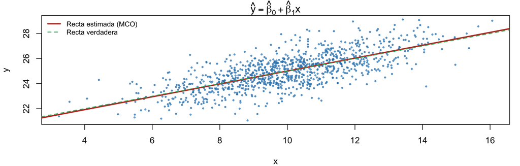

# Bondad de Ajuste: $R^2$

## Descomposición de la varianza

Para cada observación $i$: $\quad y_i - \bar{y} \;=\; (\hat{y}_i - \bar{y}) \;+\; \hat{u}_i$

- $(\hat{y}_i - \bar{y})$: desviación **explicada** por el modelo
- $\hat{u}_i$: desviación **no explicada** (residuo)

Elevando al cuadrado y sumando, el término cruzado se anula (por las CPO):

$$\text{SCT} = \text{SCE} + \text{SCR} \qquad \sum_i(y_i-\bar{y})^2 = \sum_i(\hat{y}_i-\bar{y})^2 + \sum_i\hat{u}_i^2$$

| Sigla | Nombre | ¿Qué mide? |
| --- | --- | --- |
| **SCT** | Suma de Cuadrados Total | Variación total en $y$ |
| **SCE** | Suma de Cuadrados Explicada | Variación capturada por el modelo |
| **SCR** | Suma de Cuadrados de Residuos | Variación no explicada |

## El $R^2$

El **coeficiente de determinación** $R^2$ es la fracción de la variación total de $y$ explicada por el modelo:

$$R^2 = \frac{\text{SCE}}{\text{SCT}} = 1 - \frac{\text{SCR}}{\text{SCT}}$$

**Propiedades:**

- $0 \leq R^2 \leq 1$ siempre (en modelos con intercepto)
- $R^2 = 0$: el modelo no explica nada más que la media $\bar{y}$
- $R^2 = 1$: ajuste perfecto, todos los puntos sobre la recta

```r
set.seed(44); x <- 10+rnorm(1000,0,2); y <- 20+0.5*x+rnorm(1000,0,1)
m <- lm(y ~ x)
SCT <- sum((y - mean(y))^2)
SCE <- sum((fitted(m) - mean(y))^2)
SCR <- sum(residuals(m)^2)
c(SCT = SCT, SCE = SCE, SCR = SCR, R2 = SCE/SCT, R2_check = summary(m)$r.squared)
```

```
         SCT          SCE          SCR           R2     R2_check
2025.2586424 1056.0036254  969.2550169    0.5214167    0.5214167
```

## Visualizando SCT, SCE y SCR

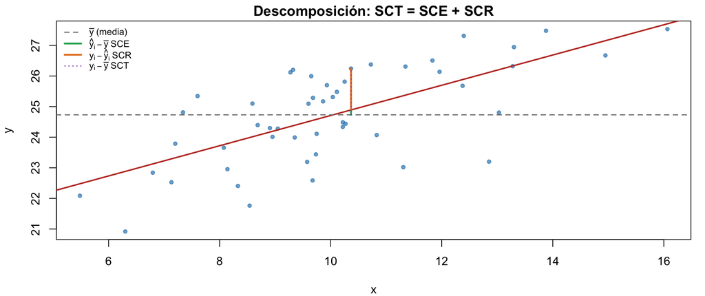

## $R^2$: ¿qué tan importante es?

Una tentación habitual: juzgar la calidad de un modelo por su $R^2$.

**Pero el objetivo determina la métrica relevante:**

| Objetivo | ¿Importa el $R^2$? |
| --- | --- |
| **Predicción** (pronosticar $y$) | Sí — un $R^2$ alto reduce el error de predicción |
| **Estimación causal** (¿cuánto afecta $x$ a $y$?) | **No** — lo que importa es $\hat\beta_1$ y su significatividad |

> *“When the researcher wants to know ‘the effect of X’, the R² has little utility. In that case, he or she should consult the relevant slope estimate.”* — Lewis-Beck & Skalaban (1991), citado en Moksony (1999)

En economía y ciencias sociales el objetivo casi siempre es **estimar efectos causales**, no predecir. Por eso el $R^2$ ocupa un lugar secundario.

## El $R^2$ en ciencias sociales

**Moksony (1999) — *“Small is beautiful”*:**

> Cuando el objetivo es **testear una teoría**, el $R^2$ es *completamente irrelevante*. Un valor bajo solo indica que $y$ depende de muchos factores además de los considerados — lo cual es esperable en ciencias sociales.

**Ejemplo clásico (Moksony):** el número de cigüeñas predice el número de nacimientos con $R^2$ alto. Nadie diría que las cigüeñas *causan* los nacimientos. El $R^2$ alto refleja la correlación espuria con el grado de urbanización.

**King (1991) — *American Journal of Political Science*:**

> *“R² measures no parameter in the regression model… Large R² values are not even empirically associated with better models in general.”*

**Ozili (2023):** en investigación empírica en ciencias sociales, un **$R^2 \geq 0{,}10$** (10%) es aceptable, *siempre que* los predictores sean estadísticamente significativos.

## Lo que sí importa

Si el objetivo es inferencia causal, la atención debe centrarse en:

**1. La estimación de $\hat\beta_1$** — ¿cuál es el efecto estimado de $x$ sobre $y$?

**2. La significatividad estadística** — ¿es ese efecto distinguible de cero?

**3. La dirección y magnitud** — ¿el signo es el esperado por la teoría? ¿el tamaño es económicamente relevante?

```r
m <- lm(y ~ x)
summary(m)$coefficients      # lo importante: β̂₁, ee, t, p-valor
```

```
              Estimate Std. Error   t value      Pr(>|t|)
(Intercept) 19.8628880 0.15825182 125.51444  0.000000e+00
x            0.5142305 0.01559477  32.97456 6.951844e-162
```

```r
summary(m)$r.squared         # dato secundario
```

```
[1] 0.5214167
```

> Un modelo con $R^2 = 0{,}08$ y $\hat\beta_1$ significativo al 1% es **más valioso para inferencia causal** que uno con $R^2 = 0{,}80$ y coeficientes espurios.

# Tests sobre los Coeficientes

## Supuesto de normalidad del error

Hasta ahora los estimadores MCO son insesgados bajo supuestos débiles. Para hacer **inferencia** (tests e IC) necesitamos conocer la **distribución muestral** de $\hat\beta_j$.

Agregamos el **supuesto de normalidad**:

$$u \sim \mathrm{N}(0,\, \sigma^2)$$

**¿Es muy restrictivo?**

No necesariamente: por el Teorema Central del Límite, con $n$ grande los estimadores MCO se distribuyen aproximadamente normal aunque $u$ no lo sea.

**¿Qué implica?**

Junto con los supuestos previos ($E(u|x)=0$, homocedasticidad), tenemos el **modelo clásico de regresión lineal**.

> Bajo normalidad del error: $y_i \mid x_i \sim \mathrm{N}(\beta_0 + \beta_1 x_i,\; \sigma^2)$

## Distribución muestral de $\hat\beta_j$

Bajo los supuestos del modelo clásico:

$$\hat\beta_j \sim \mathrm{N}\!\left(\beta_j,\; \text{Var}(\hat\beta_j)\right)$$

Como $\sigma^2$ es desconocida, se estima con $\hat\sigma^2 = \dfrac{\text{SCR}}{n - k - 1}$, donde $k$ es el número de regresores.

El **error estándar** del estimador es:

$$\text{ee}(\hat\beta_j) = \sqrt{\widehat{\text{Var}}(\hat\beta_j)}$$

Estandarizando y reemplazando $\sigma$ por $\hat\sigma$, el estadístico sigue una distribución $t$:

$$t = \frac{\hat\beta_j - \beta_j}{\text{ee}(\hat\beta_j)} \;\sim\; t_{n-k-1}$$

> Los grados de libertad son $n - k - 1$: $n$ observaciones menos $k+1$ parámetros estimados ($\beta_0, \beta_1, \ldots, \beta_k$).

## Prueba de significatividad individual

La prueba más común es testear si $x_j$ **afecta significativamente** a $y$:

$$H_0: \beta_j = 0 \qquad \text{vs.} \qquad H_1: \beta_j \neq 0$$

Bajo $H_0$, el estadístico se simplifica a:

$$t_{\hat\beta_j} = \frac{\hat\beta_j}{\text{ee}(\hat\beta_j)} \;\sim\; t_{n-k-1}$$

**Regla de decisión** (bilateral, nivel $\alpha$):

- Rechazar $H_0$ si $|t_{\hat\beta_j}| > t_{n-k-1,\,1-\alpha/2}$
- Equivalentemente: rechazar $H_0$ si $p\text{-valor} < \alpha$
- Si rechazamos $H_0$: “$x_j$ es **estadísticamente significativa**”
- Si no rechazamos $H_0$: “$x_j$ **no** es significativa (controlando por las demás $x$)”

## Leyendo el output de `summary()`

```r
set.seed(44)
x <- 10 + rnorm(1000, 0, 2);  y <- 20 + 0.5*x + rnorm(1000, 0, 1)
summary(lm(y ~ x))
```

```
Call:
lm(formula = y ~ x)

Residuals:
    Min      1Q  Median      3Q     Max
-3.3465 -0.6282  0.0263  0.6637  3.0330

Coefficients:
            Estimate Std. Error t value Pr(>|t|)
(Intercept) 19.86289    0.15825  125.51   <2e-16 ***
x            0.51423    0.01559   32.98   <2e-16 ***
---
Signif. codes:  0 '***' 0.001 '**' 0.01 '*' 0.05 '.' 0.1 ' ' 1

Residual standard error: 0.9855 on 998 degrees of freedom
Multiple R-squared:  0.5214,    Adjusted R-squared:  0.5209
F-statistic:  1087 on 1 and 998 DF,  p-value: < 2.2e-16
```

## Interpretando la tabla de coeficientes

La salida de `summary(lm())` reporta para cada $\hat\beta_j$:

| Columna | Contenido |
| --- | --- |
| `Estimate` | $\hat\beta_j$ — el estimador MCO |
| `Std. Error` | $\text{ee}(\hat\beta_j)$ — su error estándar |
| `t value` | $t_{\hat\beta_j} = \hat\beta_j / \text{ee}(\hat\beta_j)$ |
| `Pr(>\|t\|)` | $p\text{-valor}$ bilateral — bajo $H_0: \beta_j = 0$ |

Los asteriscos indican significatividad: `***` $p < 0{,}001$ · `**` $p < 0{,}01$ · `*` $p < 0{,}05$ · `.` $p < 0{,}10$

> R reporta los IC al 95% con `confint(modelo)`. El IC y el $p$-valor **son equivalentes**: si el IC al 95% no contiene 0, el $p$-valor es $< 0{,}05$.

## Intervalos de Confianza para $\hat\beta_j$

Análogo al IC para la media, un **IC al $(1-\alpha)\times 100\%$** para $\beta_j$ es:

$$\hat\beta_j \;\pm\; t_{n-k-1,\,1-\alpha/2} \cdot \text{ee}(\hat\beta_j)$$

donde $t_{n-k-1,\,1-\alpha/2}$ es el percentil $\left(1-\dfrac{\alpha}{2}\right)$ de la $t$ con $n-k-1$ grados de libertad.

```r
m <- lm(y ~ x)
confint(m, level = 0.95)   # IC 95% para β₀ y β₁
```

```
                 2.5 %     97.5 %
(Intercept) 19.5523436 20.1734325
x            0.4836282  0.5448328
```

```r
confint(m, level = 0.99)   # IC 99%
```

```
                 0.5 %     99.5 %
(Intercept) 19.4544773 20.2712987
x            0.4739841  0.5544769
```

**Interpretación:** el intervalo de 95% contiene al verdadero $\beta_j$ en el 95% de las muestras posibles. Con $n$ grande ($\gtrsim 120$), $t \approx 1{,}96$ y el IC 95% es $\hat\beta_j \pm 1{,}96\cdot\text{ee}(\hat\beta_j)$.

# Regresión Múltiple

## El Modelo de Regresión Múltiple

Extendemos la regresión simple a **$k$ variables explicativas**:

$$\boxed{y = \beta_0 + \beta_1 x_1 + \beta_2 x_2 + \cdots + \beta_k x_k + u}$$

- $\beta_0$: intercepto
- $\beta_j$: efecto **ceteris paribus** de $x_j$ sobre $y$ ($j = 1, \ldots, k$)
- $u$: error — factores no observados que afectan a $y$

**Supuesto clave (generalizado):** $E(u \mid x_1, \ldots, x_k) = 0$

El error es, en promedio, cero para **cualquier combinación** de los regresores incluidos.

> La regresión múltiple permite **controlar** por variables de confusión: $\hat\beta_j$ mide el efecto de $x_j$ sobre $y$ manteniendo los demás regresores constantes.

## Diferencias con la regresión simple

| Aspecto | Simple ($k=1$) | Múltiple ($k > 1$) |
| --- | --- | --- |
| Ecuación | $y = \beta_0 + \beta_1 x + u$ | $y = \beta_0 + \sum_{j=1}^k \beta_j x_j + u$ |
| Interpretación de $\hat\beta_j$ | Efecto de $x$ sobre $y$ | Efecto **parcial** de $x_j$, ceteris paribus |
| Sesgo por omisión | Frecuente | Reducido al incluir controles |
| Grados de libertad | $n - 2$ | $n - k - 1$ |
| Geometría | Recta en el plano | Hiperplano en $\mathbb{R}^{k+1}$ |

```r
set.seed(44);  n <- 200
x1 <- rnorm(n);  x2 <- rnorm(n);  y <- 2 + 3*x1 - x2 + rnorm(n)
lm(y ~ x1 + x2)
```

```
Call:
lm(formula = y ~ x1 + x2)

Coefficients:
(Intercept)           x1           x2
      1.975        3.054       -1.087
```

> “$\hat\beta_1$ es el efecto estimado de $x_1$ sobre $y$, **manteniendo constante $x_2$**.” La regresión múltiple “controla por” las demás variables.

## El $R^2$ nunca decrece

La misma descomposición aplica: $R^2 = \text{SCE}/\text{SCT} = 1 - \text{SCR}/\text{SCT}$

**Problema:** al agregar regresores, $R^2$ nunca puede bajar — aunque el regresor sea irrelevante.

```r
set.seed(44);  n <- 200
x1 <- rnorm(n);  x2 <- rnorm(n);  y <- 2 + 3*x1 + rnorm(n)
c(R2_simple     = summary(lm(y ~ x1))$r.squared,
  R2_con_basura = summary(lm(y ~ x1 + x2))$r.squared)
```

```
    R2_simple R2_con_basura
    0.9146223     0.9152893
```

$x_2$ es ruido puro, pero el $R^2$ no bajó. Conclusión: **el $R^2$ no es válido para comparar modelos con distinto número de regresores**.

## El $R^2$ ajustado

El $R^2$ ordinario nunca baja al agregar regresores. El $\bar{R}^2$ corrige eso penalizando cada parámetro adicional:

$$\bar{R}^2 = 1 - \frac{\text{SCR}/(n-k-1)}{\text{SCT}/(n-1)}$$

**Intuición:** agregar un regresor reduce $n-k-1$ en 1. Si SCR no cae proporcionalmente, el cociente sube y $\bar{R}^2$ baja.

|  | $R^2$ | $\bar{R}^2$ |
| --- | --- | --- |
| Al agregar un regresor | Nunca baja | Puede bajar |
| Penaliza parámetros extra | No | Sí (descuenta $k+1$) |
| Para comparar modelos con distinto $k$ | No usar | Sí (mismo $n$) |

## El $R^2$ ajustado — ejemplo

Modelo con solo $x_1$ relevante; $x_2, x_3, x_4$ son ruido puro:

```r
set.seed(44); n <- 40
x1 <- rnorm(n); x2 <- rnorm(n); x3 <- rnorm(n); x4 <- rnorm(n)
y  <- 2 + 3*x1 + rnorm(n, 0, 2)

rbind(
  k1 = c(R2 = summary(lm(y~x1))$r.squared,
         R2adj = summary(lm(y~x1))$adj.r.squared),
  k2 = c(R2 = summary(lm(y~x1+x2))$r.squared,
         R2adj = summary(lm(y~x1+x2))$adj.r.squared),
  k4 = c(R2 = summary(lm(y~x1+x2+x3+x4))$r.squared,
         R2adj = summary(lm(y~x1+x2+x3+x4))$adj.r.squared)
) |> round(3)
```

```
      R2 R2adj
k1 0.846 0.842
k2 0.872 0.866
k4 0.893 0.881
```

## Precisión y el trade-off de varianza

La varianza del estimador MCO en regresión múltiple es:

$$\text{Var}(\hat\beta_j) = \frac{\sigma^2}{\text{SCT}_j \,(1 - R^2_j)}$$

donde $R^2_j$ es el $R^2$ de regresar $x_j$ sobre **todos los demás regresores**.

**Multicolinealidad:** si $x_j$ está muy correlacionada con los otros regresores, $R^2_j \to 1 \;\Rightarrow\; \text{Var}(\hat\beta_j) \to \infty$.

| Acción | Efecto sobre sesgo | Efecto sobre varianza |
| --- | --- | --- |
| Agregar regresor relevante | Reduce sesgo | Puede aumentar varianza |
| Agregar regresor irrelevante | Sin efecto | Aumenta varianza |
| Omitir regresor correlacionado | Introduce sesgo | Reduce varianza |

> El criterio de inclusión debe ser **teórico**: incluir lo que la teoría indica, no maximizar $R^2$.

## Test $F$: ¿agregar o quitar variables?

El **test F** contrasta si un grupo de $q$ variables mejora significativamente el ajuste.

$$H_0: \beta_{k-q+1} = \cdots = \beta_k = 0 \qquad H_1: \text{al menos uno} \neq 0$$

El estadístico compara la suma de cuadrados del modelo **restringido** (sin esas variables) con el **no restringido** (con ellas):

$$F = \frac{(\text{SCR}_r - \text{SCR}_u)/q}{\text{SCR}_u/(n-k-1)} \;\sim\; F_{q,\; n-k-1} \quad \text{bajo } H_0$$

| Componente | Significado |
| --- | --- |
| $\text{SCR}_r$ | Residuos del modelo **sin** las $q$ variables |
| $\text{SCR}_u$ | Residuos del modelo **con** las $q$ variables |
| $q$ | Número de variables que se testean |
| $n-k-1$ | Grados de libertad del modelo completo |

> Si $F > F_{q,\,n-k-1,\,1-\alpha}$ (o $p < \alpha$): rechazamos $H_0$ — las variables **sí** aportan en conjunto.

## Test $F$ en R: `anova()`

```r
set.seed(44); n <- 200
x1 <- rnorm(n); z1 <- rnorm(n); z2 <- rnorm(n)
y  <- 2 + 3*x1 + rnorm(n)         # solo x1 es relevante

m_r <- lm(y ~ x1)                 # modelo restringido
m_u <- lm(y ~ x1 + z1 + z2)      # modelo completo

anova(m_r, m_u)                    # H₀: βz1 = βz2 = 0
```

```
Analysis of Variance Table

Model 1: y ~ x1
Model 2: y ~ x1 + z1 + z2
  Res.Df    RSS Df Sum of Sq      F Pr(>F)
1    198 191.20
2    196 190.07  2    1.1283 0.5818 0.5599
```

```r
set.seed(44)
x1 <- rnorm(n); x2 <- rnorm(n)
y2 <- 2 + 3*x1 + 2*x2 + rnorm(n)  # ahora x2 sí importa

anova(lm(y2 ~ x1), lm(y2 ~ x1 + x2))   # H₀: βx2 = 0
```

```
Analysis of Variance Table

Model 1: y2 ~ x1
Model 2: y2 ~ x1 + x2
  Res.Df    RSS Df Sum of Sq      F    Pr(>F)
1    198 914.17
2    197 191.05  1    723.12 745.65 < 2.2e-16 ***
---
Signif. codes:  0 '***' 0.001 '**' 0.01 '*' 0.05 '.' 0.1 ' ' 1
```

> Primer caso: $p$ grande → no rechazamos, z1/z2 se quedan fuera. Segundo caso: $p$ pequeño → rechazamos, $x_2$ debe incluirse.

## Variables dummy: regresores binarios

Un **regresor binario** (o *dummy*) codifica pertenencia a un grupo:

$$D_i = \begin{cases} 1 & \text{si la observación pertenece al grupo A} \\ 0 & \text{si pertenece al grupo de referencia} \end{cases}$$

El modelo $y_i = \beta_0 + \beta_1 D_i + u_i$ implica:

| Grupo | $E(y \mid D)$ |
| --- | --- |
| $D = 0$ (referencia) | $\beta_0$ |
| $D = 1$ | $\beta_0 + \beta_1$ |

> $\hat\beta_1$ estima la **diferencia en medias** entre el grupo $D=1$ y el grupo de referencia $D=0$.

**Ejemplos:** mujer/varón, tratado/control, urbano/rural, empleado formal/informal.

## Dummy y test de diferencia de medias

El estimador MCO en $y = \beta_0 + \beta_1 D + u$ produce exactamente:

$$\hat\beta_0 = \bar{y}_0 \qquad \hat\beta_1 = \bar{y}_1 - \bar{y}_0$$

El test $H_0: \beta_1 = 0$ es **equivalente** al $t$-test de diferencia de medias (varianzas iguales).

```r
set.seed(42)
grupo <- rep(c(0, 1), each = 50)
y     <- 10 + 3*grupo + rnorm(100, 0, 2)

# Regresión con dummy:
round(summary(lm(y ~ grupo))$coef, 4)
```

```
            Estimate Std. Error t value Pr(>|t|)
(Intercept)   9.9287     0.2954 33.6112        0
grupo         3.2727     0.4178  7.8341        0
```

```r
# t-test clásico — extraemos los valores clave:
tt <- t.test(y ~ grupo, var.equal = TRUE)
round(c(t = tt$statistic, df = tt$parameter, p.valor = tt$p.value), 4)
```

```
    t.t   df.df p.valor
-7.8341 98.0000  0.0000
```

```r
round(tt$conf.int, 4)   # IC 95% para la diferencia de medias
```

```
[1] -4.1018 -2.4437
attr(,"conf.level")
[1] 0.95
```

## Ejercicio 2.3 — Sesgo de variable omitida

```r
set.seed(555)
educacion   <- 12 + rnorm(50, mean = 5, sd = 1)
experiencia <- 20 - 3*educacion + runif(50, -5, 5)
u           <- rnorm(50, sd = 4)
ingreso     <- 100 + 5*educacion + 2*experiencia + u
```

Modelo **correcto** (incluye ambas variables):

```r
modelo_ok <- lm(ingreso ~ educacion + experiencia)
round(coef(modelo_ok), 2)    # ≈ β₀=100, β₁=5, β₂=2
```

```
(Intercept)   educacion experiencia
      92.60        5.15        1.83
```

Modelo **incompleto** (omite `experiencia`):

```r
modelo_inc <- lm(ingreso ~ educacion)
round(coef(modelo_inc), 2)   # β̂₁ muy diferente de 5
```

```
(Intercept)   educacion
     145.81       -1.27
```

> **¿Por qué el sesgo?** `experiencia` correlaciona con `educacion` (por el DGP: $\text{experiencia} = 20 - 3\cdot\text{educacion} + \ldots$) y afecta a `ingreso`. Al omitirla, $\hat\beta_1$ absorbe parte de su efecto — esto es el **sesgo de variable omitida**.

## Omitir sin sesgo: clave es la correlación

El sesgo por variable omitida **solo existe** si la variable omitida está correlacionada con los regresores incluidos.

```r
set.seed(555); n <- 500
x1 <- rnorm(n)
x2 <- rnorm(n)            # x2 independiente de x1
y  <- 5 + 3*x1 + 2*x2 + rnorm(n)

round(c(
  correcto = coef(lm(y ~ x1 + x2))["x1"],  # β̂₁ ≈ 3
  omitido  = coef(lm(y ~ x1))["x1"]         # también ≈ 3
), 3)
```

```
correcto.x1  omitido.x1
      3.035       3.035
```

```r
cor(x1, x2)   # ≈ 0: no hay correlación → no hay sesgo
```

```
[1] -0.0002438311
```

> Omitir `x2` no sesga $\hat\beta_1$ porque $\text{Cor}(x_1, x_2) \approx 0$. El error de omisión “cae” en $u$ sin contaminar la estimación.

## Variables irrelevantes: sin sesgo, menos precisión

Agregar variables **irrelevantes** no genera sesgo, pero consume grados de libertad y reduce la precisión.

```r
set.seed(44); n <- 200
x1 <- rnorm(n); z1 <- rnorm(n); z2 <- rnorm(n)
y  <- 2 + 3*x1 + rnorm(n)           # solo x1 importa

m1 <- lm(y ~ x1)
m2 <- lm(y ~ x1 + z1 + z2)

# Estimación de β₁: similar en ambos (sin sesgo)
round(c(beta_k1 = coef(m1)["x1"], beta_k3 = coef(m2)["x1"]), 3)
```

```
beta_k1.x1 beta_k3.x1
     3.045      3.043
```

```r
# Errores estándar: mayores al agregar ruido
round(c(ee_k1 = summary(m1)$coef["x1", 2],
        ee_k3 = summary(m2)$coef["x1", 2]), 4)
```

```
 ee_k1  ee_k3
0.0661 0.0664
```

> Sin sesgo en ambos casos, pero agregar ruido reduce los grados de libertad y amplía los IC — sin ningún beneficio.